# Key Risk Factors of Heart Disease in 2020

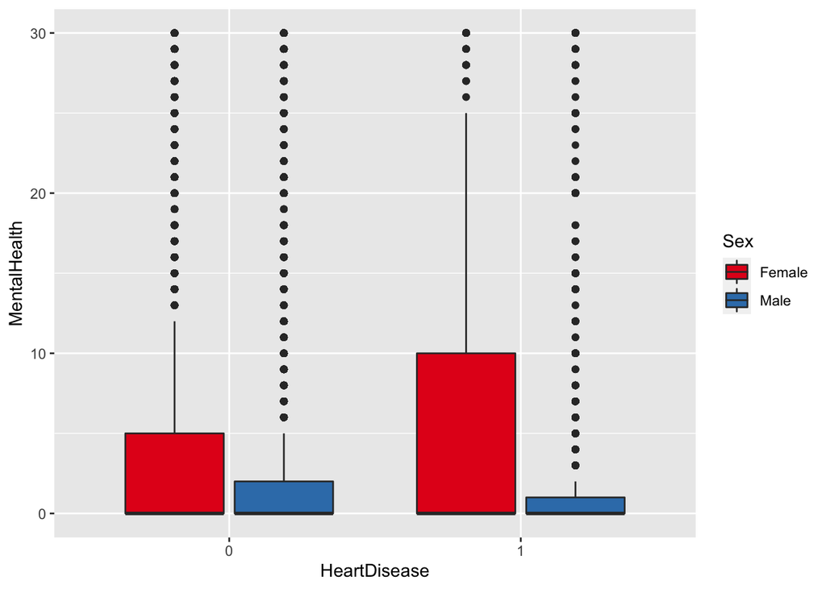

```r
ggplot(heart, aes(x = factor(HeartDisease), y = MentalHealth))+
    geom_boxplot(aes(fill = Sex))+
    xlab('HeartDisease') +
    scale_fill_brewer(palette = 'Set1', name = 'Sex')
```

```r
t.test  (male_HD$MentalHealth,
female_HD$MentalHealth)
```

```
##
##  Welch Two Sample t-test
##
## data:  male_HD$MentalHealth and female_HD$MentalHealth
## t = -22, df = 21050, p-value <2e-16
## alternative hypothesis: true difference in means is not equal to 0
## 95 percent confidence interval:
##  -2.79 -2.34
## sample estimates:
## mean of x mean of y
##      3.59      6.16
```

## Sleep Time: On average,how many hours of sleep do you get in a 24-hour period?

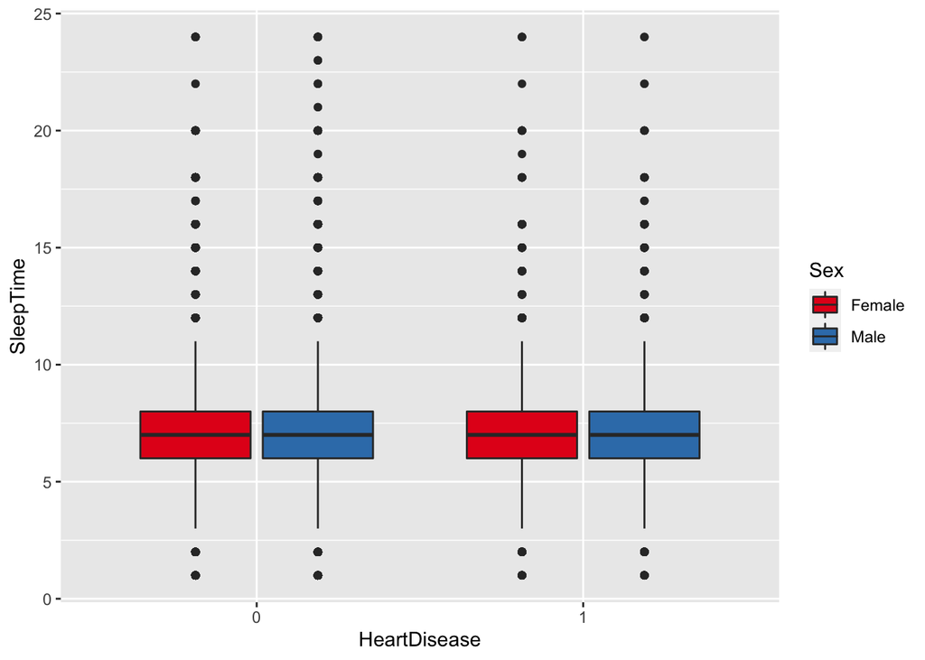

```r
ggplot(heart, aes(x = factor(HeartDisease), y = SleepTime))+
    geom_boxplot(aes(fill = Sex))+
    xlab('HeartDisease') +
    scale_fill_brewer(palette = 'Set1', name = 'Sex')
```

```r
t.test  (male_HD$SleepTime,
female_HD$SleepTime)
```

```
##
##  Welch Two Sample t-test
##
## data:  male_HD$SleepTime and female_HD$SleepTime
## t = 4, df = 22378, p-value = 2e-05
## alternative hypothesis: true difference in means is not equal to 0
## 95 percent confidence interval:
##  0.0515 0.1389
## sample estimates:
## mean of x mean of y
##      7.18      7.08
```

This lack of sleep could explain why we see that women in our data on average report feeling sick more often and could also be a contributing factors is why women are more likely to die from heart attacks than men (Noel Bairey Merz).

# Age, Race, General Health

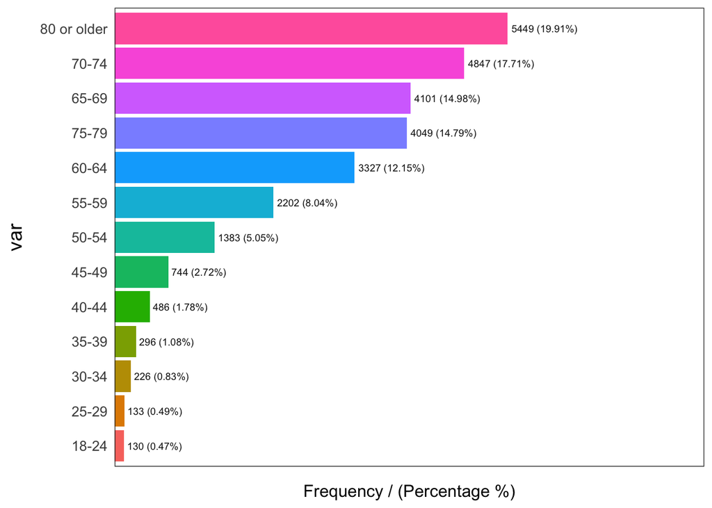

```
##            var frequency percentage cumulative_perc
## 1  80 or older      5449      19.91            19.9
## 2        70-74      4847      17.71            37.6
## 3        65-69      4101      14.98            52.6
## 4        75-79      4049      14.79            67.4
## 5        60-64      3327      12.15            79.5
## 6        55-59      2202       8.04            87.6
## 7        50-54      1383       5.05            92.6
## 8        45-49       744       2.72            95.4
## 9        40-44       486       1.78            97.1
## 10       35-39       296       1.08            98.2
## 11       30-34       226       0.83            99.0
## 12       25-29       133       0.49            99.5
## 13       18-24       130       0.47           100.0
```

```r
freq(HD$AgeCategory)
```

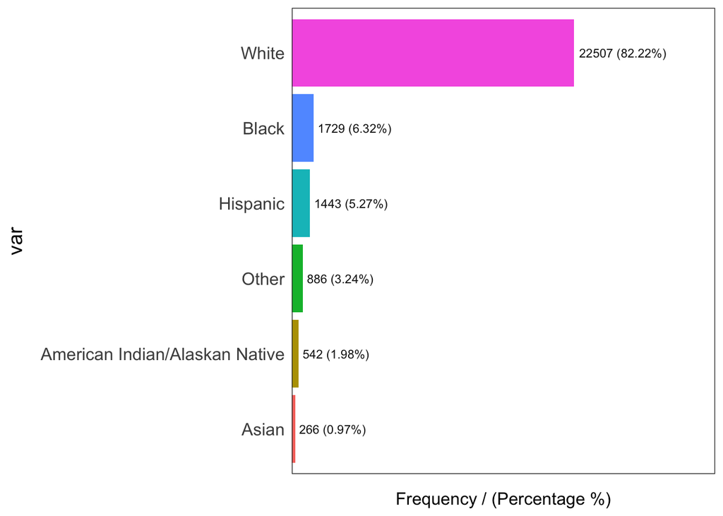

```
##                              var frequency percentage cumulative_perc
## 1                          White     22507      82.22            82.2
## 2                          Black      1729       6.32            88.5
## 3                       Hispanic      1443       5.27            93.8
## 4                          Other       886       3.24            97.0
## 5 American Indian/Alaskan Native       542       1.98            99.0
## 6                          Asian       266       0.97           100.0
```

```r
freq(HD$Race)
```

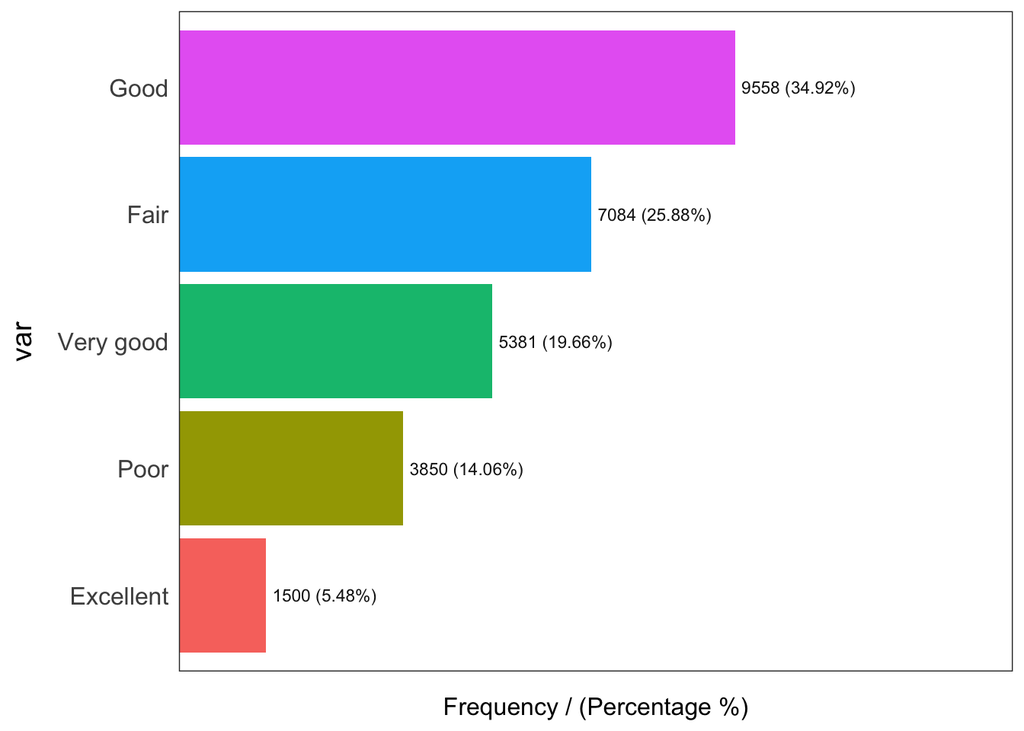

```
##         var frequency percentage cumulative_perc
## 1      Good      9558      34.92            34.9
## 2      Fair      7084      25.88            60.8
## 3 Very good      5381      19.66            80.5
## 4      Poor      3850      14.06            94.5
## 5 Excellent      1500       5.48           100.0
```

```r
freq(HD$GenHealth)
```

When looking at the population make-up of respondents who do have heart, we see that a higher percentage of respondents are 60 and older, with 82% being of Caucasian descent. At the time of the interview they also said they felt their overall health is good. This may be a limiting factor for future research since, once again, the sample does not have many data points from non-Caucasian individuals. We also see that most of our respondents with heart disease are older above 60 years of age, this is in-line with theory.

Even though a logit regression seems more to estimate whether or not an individual gets heart disease, we can still use a linear regression in our exploratory stages to find the best fitting model.

# Liner Regression on Sex

```r
reg_1 <- lm(HeartDisease~Sex+BMI, data=heart)
summary (reg_1)
```

```
##
## Call:
## lm(formula = HeartDisease ~ Sex + BMI, data = heart)
##
## Residuals:
##     Min      1Q  Median      3Q     Max
## -0.2521 -0.1024 -0.0805 -0.0587  0.9677
##
## Coefficients:
##             Estimate Std. Error t value Pr(>|t|)
## (Intercept) 5.03e-03   2.29e-03     2.2    0.028 *
## SexMale     3.85e-02   9.87e-04    39.0   <2e-16 ***
## BMI         2.20e-03   7.76e-05    28.3   <2e-16 ***
## ---
## Signif. codes:  0 '***' 0.001 '**' 0.01 '*' 0.05 '.' 0.1 ' ' 1
##
## Residual standard error: 0.279 on 319792 degrees of freedom
## Multiple R-squared:  0.0074, Adjusted R-squared:  0.00739
## F-statistic: 1.19e+03 on 2 and 319792 DF,  p-value: <2e-16
```

```r
reg_2 <- lm(HeartDisease~Sex+BMI+ PhysicalHealth+MentalHealth + SleepTime, data=heart)
summary (reg_2)
```

```
##
## Call:
## lm(formula = HeartDisease ~ Sex + BMI + PhysicalHealth + MentalHealth +
##     SleepTime, data = heart)
##
## Residuals:
##     Min      1Q  Median      3Q     Max
## -0.3585 -0.0918 -0.0726 -0.0425  1.0001
##
## Coefficients:
##                 Estimate Std. Error t value Pr(>|t|)
## (Intercept)    -2.18e-02   3.41e-03   -6.40  1.5e-10 ***
## SexMale         4.22e-02   9.78e-04   43.10  < 2e-16 ***
## BMI             1.43e-03   7.70e-05   18.55  < 2e-16 ***
## PhysicalHealth  6.18e-03   6.41e-05   96.37  < 2e-16 ***
## MentalHealth   -4.95e-04   6.44e-05   -7.69  1.5e-14 ***
## SleepTime       3.95e-03   3.41e-04   11.58  < 2e-16 ***
## ---
## Signif. codes:  0 '***' 0.001 '**' 0.01 '*' 0.05 '.' 0.1 ' ' 1
##
## Residual standard error: 0.275 on 319789 degrees of freedom
## Multiple R-squared:  0.0367, Adjusted R-squared:  0.0367
## F-statistic: 2.44e+03 on 5 and 319789 DF,  p-value: <2e-16
```

```r
reg_3 <- lm(HeartDisease~Sex+BMI+ PhysicalHealth+MentalHealth + SleepTime + AgeCategory + Race, data=heart)
summary (reg_3)
```

```
##
## Call:
## lm(formula = HeartDisease ~ Sex + BMI + PhysicalHealth + MentalHealth +
##     SleepTime + AgeCategory + Race, data = heart)
##
## Residuals:
##     Min      1Q  Median      3Q     Max
## -0.4622 -0.1213 -0.0515 -0.0051  1.0643
##
## Coefficients:
##                         Estimate Std. Error t value Pr(>|t|)
## (Intercept)            -5.43e-02   5.25e-03  -10.34  < 2e-16 ***
## SexMale                 5.24e-02   9.54e-04   54.92  < 2e-16 ***
## BMI                     2.07e-03   7.62e-05   27.15  < 2e-16 ***
## PhysicalHealth          4.79e-03   6.31e-05   75.89  < 2e-16 ***
## MentalHealth            1.09e-03   6.38e-05   17.11  < 2e-16 ***
## SleepTime              -1.67e-03   3.34e-04   -5.00  5.8e-07 ***
## AgeCategory25-29       -1.57e-03   2.75e-03   -0.57   0.5685
## AgeCategory30-34        1.19e-03   2.69e-03    0.44   0.6566
## AgeCategory35-39        3.05e-03   2.63e-03    1.16   0.2463
## AgeCategory40-44        1.05e-02   2.62e-03    4.02  5.7e-05 ***
## AgeCategory45-49        1.94e-02   2.60e-03    7.45  9.4e-14 ***
## AgeCategory50-54        3.72e-02   2.51e-03   14.78  < 2e-16 ***
## AgeCategory55-59        5.54e-02   2.43e-03   22.77  < 2e-16 ***
## AgeCategory60-64        8.02e-02   2.38e-03   33.69  < 2e-16 ***
## AgeCategory65-69        1.05e-01   2.38e-03   44.33  < 2e-16 ***
## AgeCategory70-74        1.44e-01   2.42e-03   59.31  < 2e-16 ***
## AgeCategory75-79        1.78e-01   2.63e-03   67.54  < 2e-16 ***
## AgeCategory80 or older  2.19e-01   2.57e-03   85.36  < 2e-16 ***
## RaceAsian              -3.33e-02   4.75e-03   -7.00  2.5e-12 ***
## RaceBlack              -2.65e-02   4.09e-03   -6.48  9.0e-11 ***
## RaceHispanic           -2.46e-02   4.03e-03   -6.09  1.1e-09 ***
## RaceOther              -1.62e-02   4.49e-03   -3.62   0.0003 ***
## RaceWhite              -2.50e-02   3.74e-03   -6.70  2.1e-11 ***
## ---
## Signif. codes:  0 '***' 0.001 '**' 0.01 '*' 0.05 '.' 0.1 ' ' 1
##
## Residual standard error: 0.266 on 319772 degrees of freedom
## Multiple R-squared:  0.094,  Adjusted R-squared:  0.0939
## F-statistic: 1.51e+03 on 22 and 319772 DF,  p-value: <2e-16
```

With each new addition of a variable, we see that the adjusted R-squared is increasing indicating that the model fit is improving. However, the fit statistic is still quite low.

# Heart Disease & Secondary Illnesses

In this part we are Identifying whether Heart Disease and secondary illnesses have correlation or not(are they dependent or independent?).

In this part we are Identifying whether Heart Disease and secondary illnesses have correlation or not(are they dependent or independent?).

```r
# We are seperating our desired variables to test them in an easier way.
diseases <- data.frame (heart$HeartDisease,
                        heart$Stroke,
                        heart$Diabetic,
                        heart$Asthma,
                        heart$KidneyDisease,
                        heart$SkinCancer)

# Rename columns

names(diseases) <- c ('heart_disease',
                      'stroke',
                      'diabetic',
                      'asthma',
                      'kidney_disease',
                      'skin_cancer')
```

# Corellation Matrix and Correlation Plot Between Diseases

```r
cor_matrix<-cor(diseases)
cor_matrix
```

[output not shown]

```r
model.matrix(~0+., data=diseases) %>%
     cor(use="pairwise.complete.obs") %>%
    ggcorrplot(show.diag = F, type="upper", lab=TRUE, lab_size=2)
```

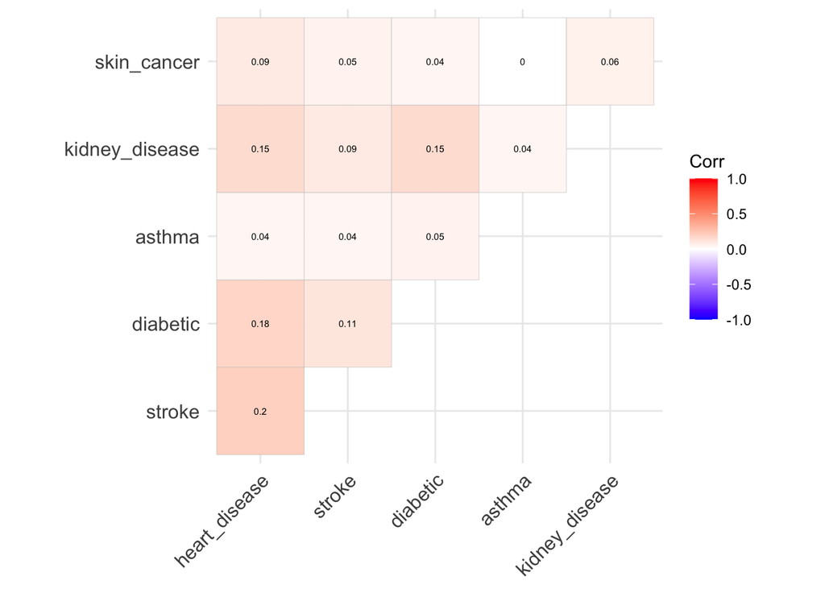

From the above correlation test we can see that overall Correlations are not particularly strong. Heartdisease has more correlation with stroke than any other secondary illnesses(Which is not a surprise generally). Diabetes is correlated with heart disease and Kidney disease, Less with Stroke. Skin cancer shows negligible correlation with all other diseases. overall, we can see that only stroke, diabetes and kidney disease have considerable correlation with heart disease. Not only from our correlation test, but as per center for disease control and prevention, Common heart disorders can increase your risk for stroke. For example, coronary artery disease increases your risk for stroke, because plaque builds up in the arteries and blocks the flow of oxygen-rich blood to the brain. Also diabetes increases your risk for stroke(Stroke vs Diabetes in our correlation plot ).Diabetes causes sugars to build up in the blood and prevent oxygen and nutrients from getting to the various parts of your body, including your brain. High blood pressure is also common in people with diabetes. High blood pressure is the leading cause of stroke and is the main cause for increased risk of stroke among people with diabetes (CDC Stroke Fact sheet). (https://www.cdc.gov/stroke/conditions.htm#:~:text=Common%20heart%20disorders%20can%20increase,rich%20blood%20to%20the%20brain.)

# Determining Independence Between Diseases

After finding the correlation between variables we are now performing a chi-suare test of independence to find out whether the varibles are dependent or independent with each other. The Chi-Square test of independence is used to determine if there is a significant relationship between two nominal (categorical) variables(All the variables we have here are already categorical). In a more general sense, it tests to see whether distributions of categorical variables differ from each another.The frequency of each category for one nominal variable is compared across the categories of the second nominal variable. The data can be displayed in a contingency table where each row represents a category for one variable and each column represents a category for the other variable. The null hypothesis for this test is that there is no relationship between primary disease heartDisease and other secondary illnesses. The alternative hypothesis is that there is a relationship between heartDisease and secondary illnesses.

[figure not shown]